# explanatory_analysis slides

**Loan investigation findings**

**Investigation Overview**

We are meant here to give insights about loan dataset answering questions like  
what factors that effect the loan status?  
What affects the borrower’s APR?

We begin by cleaning the dataset which consisted of 81 variables, the main focus fall on just these variables  
{ 'ListingCreationDate', 'Term', 'LoanStatus', 'ClosedDate', 'BorrowerAPR', 'ProsperRating (Alpha)', 'ListingCategory (numeric)', 'Occupation', 'EmploymentStatus', 'IsBorrowerHomeowner', 'DebtToIncomeRatio', 'IncomeRange', 'StatedMonthlyIncome', 'Recommendations', 'LoanOriginalAmount', 'MonthlyLoanPayment', 'Investors' }

Here we will give a short overview of their meanings, then we will see some correlations between them and build up until we get a compelete overview and have a meaningful insights about the factors we are interested in.

```
							schema_meanings

*ListingCreationDate :  The date the listing was created.
*Term :  The length of the loan expressed in months.
*LoanStatus :  The current status of the loan: Cancelled,  Chargedoff, Completed, Current, Defaulted, FinalPaymentInProgress, PastDue. The PastDue status will be accompanied by a delinquency bucket.
*ClosedDate :  Closed date is applicable for Cancelled, Completed, Chargedoff and Defaulted loan statuses.
*BorrowerAPR :  The Borrower's Annual Percentage Rate (APR) for the loan.
*ProsperRating (Alpha) :  The Prosper Rating assigned at the time the listing was created between AA - HR.  Applicable for loans originated after July 2009.
*ListingCategory (numeric) :  The category of the listing that the borrower selected when posting their listing: 0 - Not Available, 1 - Debt Consolidation, 2 - Home Improvement, 3 - Business, 4 - Personal Loan, 5 - Student Use, 6 - Auto, 7- Other, 8 - Baby&Adoption, 9 - Boat, 10 - Cosmetic Procedure…
*Occupation :  The Occupation selected by the Borrower at the time they created the listing.
*EmploymentStatus :  The employment status of the borrower at the time they posted the listing.
*IsBorrowerHomeowner :  A Borrower will be classified as a homowner if they have a mortgage on their credit profile or provide documentation confirming they are a homeowner.
*DebtToIncomeRatio :  The debt to income ratio of the borrower at the time the credit profile was pulled. This value is Null if the debt to income ratio is not available. This value is capped at 10.01 (any debt to income ratio larger than 1000% will be returned as 1001%).
*IncomeRange :  The income range of the borrower at the time the listing was created.
*StatedMonthlyIncome :  The monthly income the borrower stated at the time the listing was created.
*Recommendations :  Number of recommendations the borrower had at the time the listing was created.
*LoanOriginalAmount :  The origination amount of the loan.
*MonthlyLoanPayment :  The scheduled monthly loan payment.
*Investors :  The number of investors that funded the loan.
```

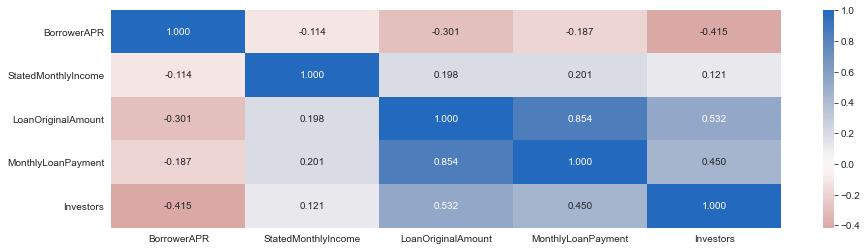

from the correlation map above we can see that there is a negative correlation between Investors and BorrowerAPR and of course the monthy loan payment increases as the Original loan increases

Now we will see some relations associated with BorrowerAPR

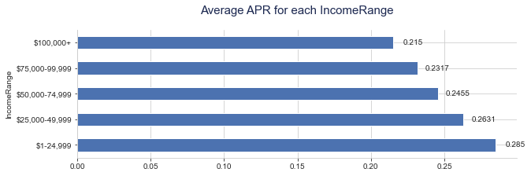

People with the lower incomeRange tend to have higher average APR, it is strange though.  
mabye due to their payment-delay?  
or maybe due to they have less investors?  
or mabye due to the fact that these people tend to NEED loans more than the other (e.g. for houses or Autos ..etc.).

We will see the relation between IncomeRange and the others to see why lower income range have higher APR.

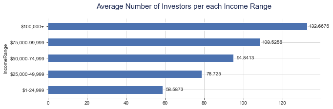

it seems like what we said above was true, people with lower income range tend to have fewer investors.

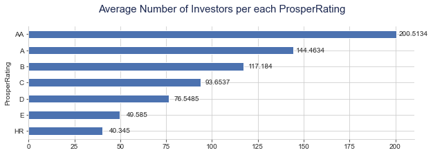

Invistors increase is indication of a good ProsperRating.

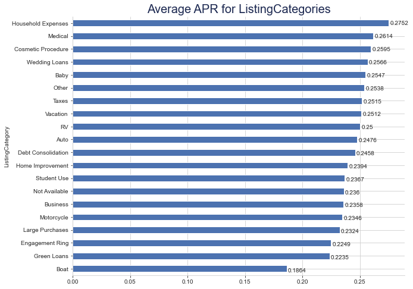

So, it seems that the HIGHEST APR tends to go for Household Expenses followed by Medical expenses.

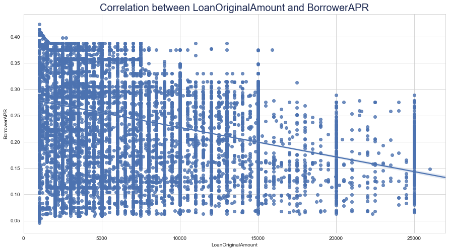

APR decreases as the LoanOriginalAmount increases. seems convincing.

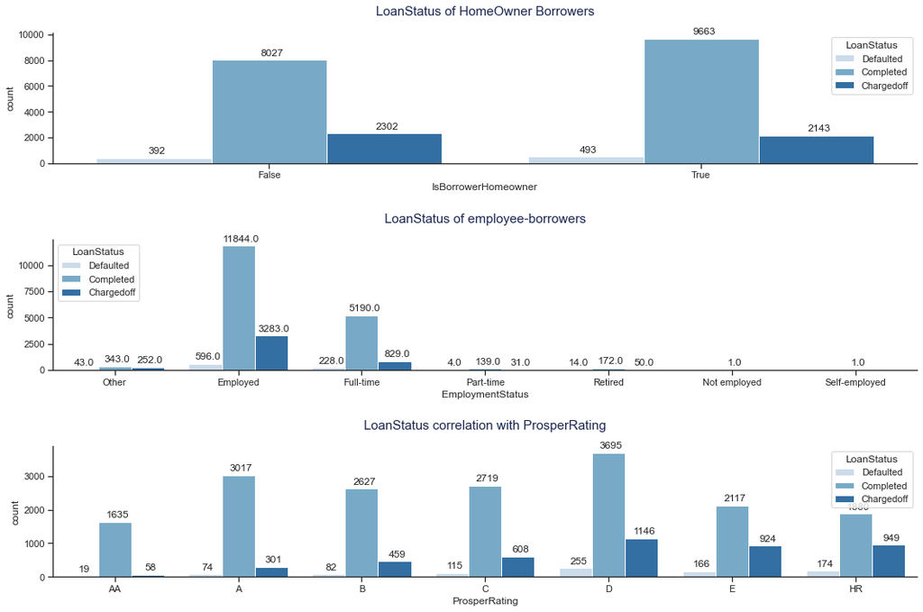

Borrowers with their own houses tend to complete the loan more than the others.  
Number of Chargedoff borrowers tend to follow the ProsperRating scale, as risk increases charing increases which is pretty obvious :D

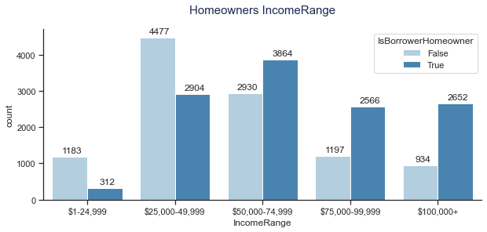

Ratio between people with higher IncomeRange who own houses to who don't is higher than the people with lower IncomeRange and therefore this category have higher creditability for completing the loan which confirms the previous results.

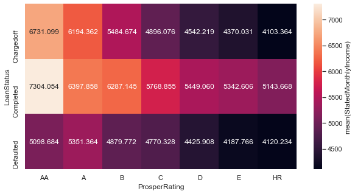

This summarize the correlations between monthlyIncome, ProsperRating, and LoanStatus As MonthlyIncome increases, the borrower gain a good prosperrating and eventually he completes the loan.

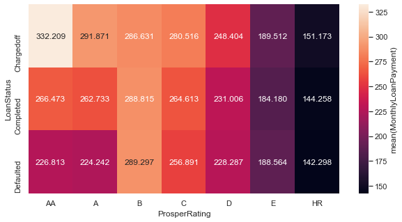

We got an interesting results here, indicating that if the monthly loan payment increased over a certain point, EVEN IF the borrower is considered in a AA-ProsperRating-category, debt is unlikely to be collected.

**Conclusions**

Here we focused on giving insights about two questions: